# DGE_analysis_exercises_answer_key

2023-08-07

# Using DESeq2 for gene-level differential expression analysis

- The metadata below describes an RNA-seq analysis experiment, in which the metadata table below and associated count matrix have been loaded into R as `meta` and `counts`, respectively. Additionally, all of the appropriate libraries have been loaded for you. Use the information in the table to answer the following questions.

  **meta**

  |  | Genotype | Celltype | Batch |
  | --- | --- | --- | --- |
  | sample1 | Wt | typeA | second |
  | sample2 | Wt | typeA | second |
  | sample3 | Wt | typeA | first |
  | sample4 | KO | typeA | first |
  | sample5 | KO | typeA | first |
  | sample6 | KO | typeA | second |
  | sample7 | Wt | typeB | second |
  | sample8 | Wt | typeB | first |
  | sample9 | Wt | typeB | second |
  | sample10 | KO | typeB | first |
  | sample11 | KO | typeB | first |
  | sample12 | KO | typeB | second |

  **NOTE: This is an exercise in thinking about running DESeq2. You do not need to run any code in R/RStudio. Refer to the materials/lessons from class to answer the following questions.**

  **a.** Reorder the columns of the `counts` dataset such that `rownames(meta) == colnames(counts)`.

```r
    idx <- match(rownames(meta), colnames(counts))

    counts <- counts[ , idx]
```

```
**b.** Provide the line of code used to create a DESeqDataSet object called `dds` in which `Genotype` is the factor of interest and `Celltype` and `Batch` are other contributing sources of variation in your data.
```

```r
    dds <- DESeqDataSetFromMatrix(countData = data, colData = meta, design = ~ Celltype + Batch + Genotype)
```

```
**c.** Provide the line of code required to run DESeq2 on `dds`.
```

```r
    dds <- DESeq(dds)
```

```
**d.** Provide the line of code to create a dispersion plot.
```

```r
    plotDispEsts(dds)
```

```
**e.** Provide the line of code to return the results of a Wald test comparison for `Celltype` categories `typeA` versus `typeB` (i.e the fold changes reported should reflect gene expression changes relative to `typeB`).
```

```r
    res_tableCelltype <- results(dds, contrast = c("Celltype", "typeA" , "typeB"))
```

```
**f.** Provide the line of code to return the results with log2 fold change shrinkage performed.
```

```r
    res_tableCelltype <- lfcShrink(dds, contrast=c("Celltype", "typeA" , "typeB"), res=res_tableCelltype)
```

```
**g.** Provide the line of code to write the results of the Wald test with shrunken log2 fold changes to file.
```

```r
    write.table(res_tableCelltype, file="res_Celltype.txt", sep="\t", quote=F, col.names=NA)
```

```
**h.** Provide the line of code to subset the results to return those genes with adjusted p-value < 0.05 and logFold2Change > 1.
```

```r
    filter(res_tableCelltype, padj < 0.05 & abs(log2FoldChange) > 1)
```

# Working with the DESeq2 results table

- Using the DESeq2_expression_analysis.Rmd script change the thresholds for adjusted p-value and log2 fold change to the following values:

```r
    padj.cutoff <- 0.01

    lfc.cutoff <- 1.5
```

```
Using these new cutoffs, perform the following steps:

**a.** Subset `res_tableOE` to only return those rows that meet the criteria we specified above (adjusted p-values < 0.01 and log fold changes >1.5). Save the subsetted table to a data frame called `sig_table_hw_oe`. You'll have to load the res_tableOE first. Write the code below:
```

```r
res_tableOE = readRDS("../data/res_tableOE.rds")

w = which(res_tableOE$padj < 0.01 & abs(res_tableOE$log2FoldChange) > 1.5)
sig_table_hw_oe <- res_tableOE[w,]
```

[output not shown]

```r
summary(sig_table_hw_oe)
```

```
##
## out of 50 with nonzero total read count
## adjusted p-value < 0.05
## LFC > 0 (up)       : 41, 82%
## LFC < 0 (down)     : 9, 18%
## outliers [1]       : 0, 0%
## low counts [2]     : 0, 0%
## (mean count < 5)
## [1] see 'cooksCutoff' argument of ?results
## [2] see 'independentFiltering' argument of ?results
```

```
**c.** Get the gene names from `sig_table_hw_oe` and save them to a vector called `sigOE_hw`. Write the code below:
```

```r
sigOE_hw <- rownames(sig_table_hw_oe)
```

```
**d.** Write the `sigOE_hw` vector of gene names to a file called `sigOE_hw.txt` using the `write()` function. Ensure the genes are listed in a single column. Write the code below.
```

```r
write(sigOE_hw, file="../results/sigOE_hw.txt", ncol=1)
```

# Visualizing Results

- For the genes that are differentially expressed in the knockdown versus control comparison (`res_tableKD`), plot an expression heatmap using normalized counts and `pheatmap()` following the instructions below. Write the code you would use to create the heatmap.

```r
normalized_counts <- read.delim("../data/normalized_counts.txt",row.names = 1)
meta <- read.table("../meta/Mov10_full_meta.txt", header=T, row.names=1)

sigKD <- readRDS("../data/sigKD.rds")

colnames(normalized_counts)
```

```
## [1] "Irrel_kd_1" "Irrel_kd_2" "Irrel_kd_3" "Mov10_kd_2" "Mov10_kd_3"
## [6] "Mov10_oe_1" "Mov10_oe_2" "Mov10_oe_3"
```

```r
## Extract normalized expression for significant genes
norm_KDsig <- normalized_counts[sigKD$gene, c(1,2,6,7,8)]

## Annotate our heatmap (optional)
annotation <- meta[c(1,2,6,7,8), "sampletype", drop = FALSE]
    # Or
annotation <- meta[meta$sampletype != "MOV10_overexpression", "sampletype", drop = FALSE]
```

```
**b.** Set up a heat.colors vector using a palette of your choice from brewer.pal (make sure it is different from the one used in class).
```

```r
library(RColorBrewer)
heat.colors <- brewer.pal(6, "YlGnBu")
```

```
**c.** Plot the heatmap without clustering the columns.
```

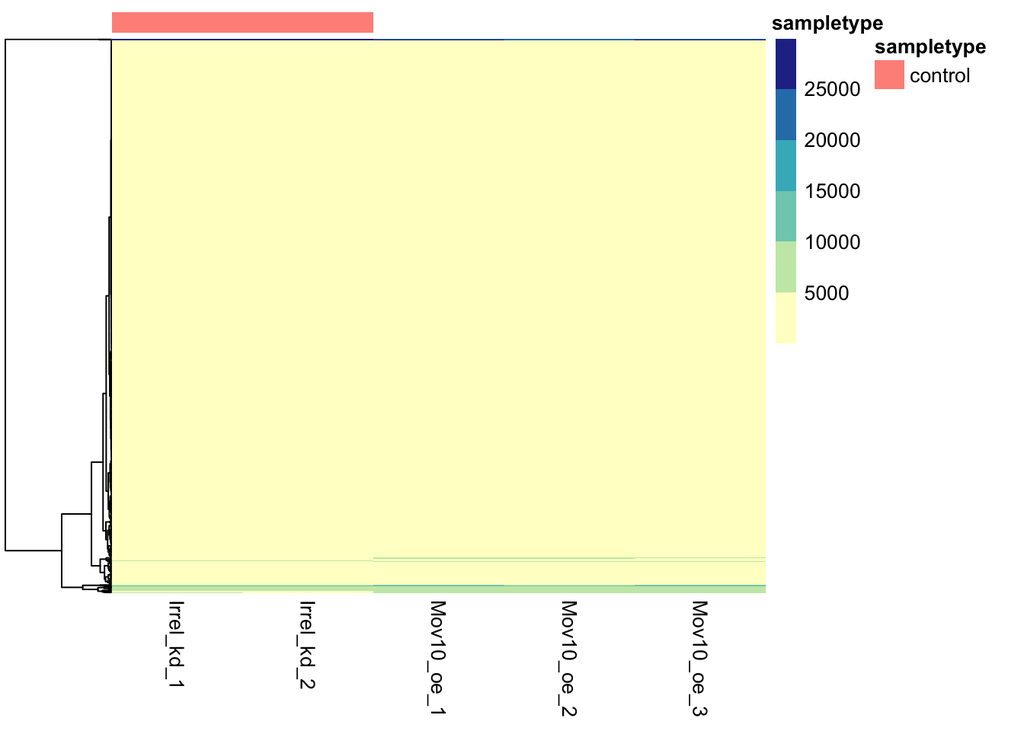

[output not shown]

```r
library(pheatmap)
pheatmap(norm_KDsig, color = heat.colors,
                cluster_rows = T, cluster_cols = F,
                show_rownames=F, annotation = annotation,
                fontsize = 10,  fontsize_row = 10, height=20)
```

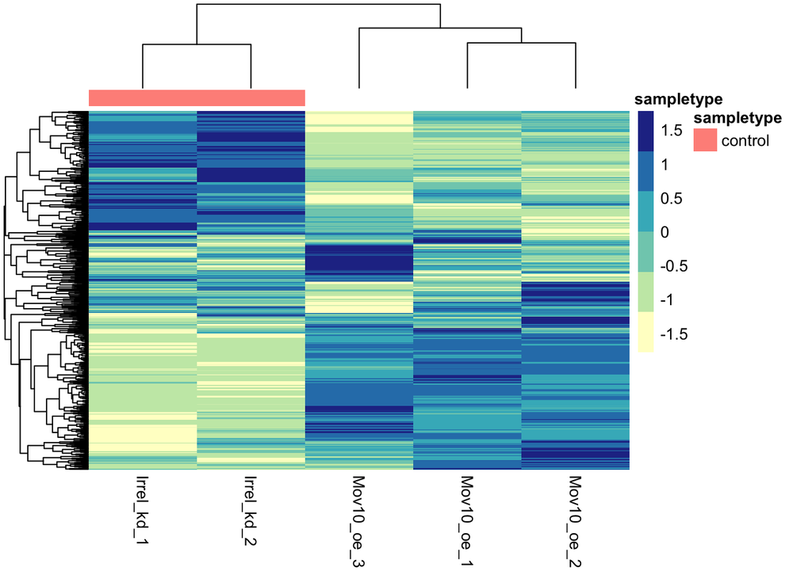

```r
pheatmap(norm_KDsig, color = heat.colors,
                cluster_rows = T, scale="row",
                show_rownames=F, annotation= annotation,
                fontsize = 10,  fontsize_row = 10, height=20)
```

# Use significant gene lists to find overlaps between the two comparisons

- Using the original cutoff values, perform the following steps:

```r
    padj.cutoff <- 0.05

    lfc.cutoff <- 0.58
```

```
**a.** Create separate vectors with gene names for up-regulated genes and down-regulated genes from `res_tableOE` and save as `up_OE` and `down_OE`, respectively. Write the code below:
```

```r
up_OE<- row.names(res_tableOE)[which(res_tableOE$padj < padj.cutoff & res_tableOE$log2FoldChange > lfc.cutoff)]

down_OE <- row.names(res_tableOE)[which(res_tableOE$padj < padj.cutoff & res_tableOE$log2FoldChange < -lfc.cutoff)]
```

```
**b.** Create separate vectors with gene names for up-regulated genes and down-regulated genes from `res_tableKD` and save as `up_KD` and `down_KD`, respectively. Write the code below:
```

```r
res_tableKD <- readRDS("../data/res_tableKD.rds")

up_KD <- row.names(res_tableKD)[which(res_tableKD$padj < padj.cutoff & res_tableKD$log2FoldChange > lfc.cutoff)]

down_KD <- row.names(res_tableKD)[which(res_tableKD$padj < padj.cutoff & res_tableKD$log2FoldChange < -lfc.cutoff)]
```

```
**c.** Test for overlaps between the lists:

- How many, and which genes in `up_OE` are also in `down_KD`?
```

```r
        length(up_OE[up_OE %in% down_KD])
```

```
## [1] 17
```

```r
        # Or
        length(down_KD[down_KD %in% up_OE])
```

```
## [1] 17
```

```
- How many, and which genes in `up_KD` are also in `down_OE`?
```

```r
        length(up_KD[up_KD %in% down_OE])
```

```
## [1] 13
```

```r
        # Or
        length(down_OE[down_OE %in% up_KD])
```

```
## [1] 13
```